# **Regression Project: Boston House Price Prediction**

# **Marks: 60**

Welcome to the project on regression. We will use the **Boston house price dataset** for this project.

## **Objective**

The problem at hand is to **predict the housing prices of a town or a suburb based on the features of the locality provided to us**. In the process, we need to **identify the most important features affecting the price of the house**. We need to employ techniques of data preprocessing and build a linear regression model that predicts the prices for the unseen data.

## **Dataset**

Each record in the database describes a house in Boston suburb or town. The data was drawn from the Boston Standard Metropolitan Statistical Area (SMSA) in 1970. Detailed attribute information can be found below:

Attribute Information:

- **CRIM:** Per capita crime rate by town
- **ZN:** Proportion of residential land zoned for lots over 25,000 sq.ft.
- **INDUS:** Proportion of non-retail business acres per town
- **CHAS:** Charles River dummy variable (= 1 if tract bounds river; 0 otherwise)
- **NOX:** Nitric Oxide concentration (parts per 10 million)
- **RM:** The average number of rooms per dwelling
- **AGE:** Proportion of owner-occupied units built before 1940
- **DIS:** Weighted distances to five Boston employment centers
- **RAD:** Index of accessibility to radial highways
- **TAX:** Full-value property-tax rate per 10,000 dollars
- **PTRATIO:** Pupil-teacher ratio by town
- **LSTAT:** % lower status of the population
- **MEDV:** Median value of owner-occupied homes in 1000 dollars

## **Importing the necessary libraries**

```python
# Libraries to help with reading and manipulating data
import numpy as np
import pandas as pd

# Library to split the data
from sklearn.model_selection import train_test_split

# Libaries to help with data visualization
import matplotlib.pyplot as plt
import seaborn as sns

# Removes the limit for the number of displayed columns
pd.set_option("display.max_columns", None)

# Sets the limit for the number of displayed rows
pd.set_option("display.max_rows", 100)

# Import libraries for building linear regression model
from statsmodels.formula.api import ols
import statsmodels.api as sm
from sklearn.linear_model import LinearRegression

# To build models for prediction
from sklearn.model_selection import train_test_split, cross_val_score, KFold
from sklearn.linear_model import LinearRegression, Ridge, Lasso
from sklearn.tree import DecisionTreeRegressor
from sklearn.ensemble import RandomForestRegressor,BaggingRegressor

# Import library for preparing data
from sklearn.model_selection import train_test_split

# To scale the data using z-score
from sklearn.preprocessing import StandardScaler
from sklearn.preprocessing import MinMaxScaler

# To check model performance
from sklearn.metrics import make_scorer,mean_squared_error, r2_score, mean_absolute_error

import warnings
warnings.filterwarnings("ignore")
```

### Loading the dataset

```python
# let colab access my google drive
from google.colab import drive
drive.mount('/content/drive')

data = pd.read_csv("/content/drive/MyDrive/MIT-Foundations-for-Data-Science/Elective Project/Boston.csv")
```

## Data Overview

```python
print(f"There are {data.shape[0]} rows and {data.shape[1]} columns.")
```

```
There are 506 rows and 13 columns.
```

```python
data.head()
```

|  | CRIM | ZN | INDUS | CHAS | NOX | RM | AGE | DIS | RAD | TAX | PTRATIO | LSTAT | MEDV |
| --- | --- | --- | --- | --- | --- | --- | --- | --- | --- | --- | --- | --- | --- |
| 0 | 0.00632 | 18.0 | 2.31 | 0 | 0.538 | 6.575 | 65.2 | 4.0900 | 1 | 296 | 15.3 | 4.98 | 24.0 |
| 1 | 0.02731 | 0.0 | 7.07 | 0 | 0.469 | 6.421 | 78.9 | 4.9671 | 2 | 242 | 17.8 | 9.14 | 21.6 |
| 2 | 0.02729 | 0.0 | 7.07 | 0 | 0.469 | 7.185 | 61.1 | 4.9671 | 2 | 242 | 17.8 | 4.03 | 34.7 |
| 3 | 0.03237 | 0.0 | 2.18 | 0 | 0.458 | 6.998 | 45.8 | 6.0622 | 3 | 222 | 18.7 | 2.94 | 33.4 |
| 4 | 0.06905 | 0.0 | 2.18 | 0 | 0.458 | 7.147 | 54.2 | 6.0622 | 3 | 222 | 18.7 | 5.33 | 36.2 |

```python
# Check the data types for all the columns as well as for missing data
data.info()
```

```
<class 'pandas.core.frame.DataFrame'>
RangeIndex: 506 entries, 0 to 505
Data columns (total 13 columns):
 #   Column   Non-Null Count  Dtype
---  ------   --------------  -----
 0   CRIM     506 non-null    float64
 1   ZN       506 non-null    float64
 2   INDUS    506 non-null    float64
 3   CHAS     506 non-null    int64
 4   NOX      506 non-null    float64
 5   RM       506 non-null    float64
 6   AGE      506 non-null    float64
 7   DIS      506 non-null    float64
 8   RAD      506 non-null    int64
 9   TAX      506 non-null    int64
 10  PTRATIO  506 non-null    float64
 11  LSTAT    506 non-null    float64
 12  MEDV     506 non-null    float64
dtypes: float64(10), int64(3)
memory usage: 51.5 KB
```

```python
# Checking the number of unique values in each column
data.nunique()
```

```
CRIM       504
ZN          26
INDUS       76
CHAS         2
NOX         81
RM         446
AGE        356
DIS        412
RAD          9
TAX         66
PTRATIO     46
LSTAT      455
MEDV       229
dtype: int64
```

```python
# Another way for checking for missing values in the data
data.isnull().sum()
```

```
CRIM       0
ZN         0
INDUS      0
CHAS       0
NOX        0
RM         0
AGE        0
DIS        0
RAD        0
TAX        0
PTRATIO    0
LSTAT      0
MEDV       0
dtype: int64
```

## Observations

1. There are 506 rows and 13 columns.
2. The data is entirely numerical.
3. There are no negative numbers.
4. There are no categorical variables.
5. There are no single value variables so we will not be dropping any columns.

## Sanity checks

1. There are no duplicates.
2. There are no null values.

## Exploratory Data Analysis (EDA)

- EDA is an important part of any project involving data.
- It is important to investigate and understand the data better before building a model with it.
- A few questions have been mentioned below which will help you approach the analysis in the right manner and generate insights from the data.
- A thorough analysis of the data, in addition to the questions mentioned below, should be done.

**Questions:**

1. What does the distribution of 'MEDV' look like?
2. What can we infer form the correlation heatmap? Is there correlation between the dependent and independent variables?
3. What are all the inferences that can be found by doing univariate analysis for different variables?
4. Do bivariate analysis to visualize the relationship between the features having significant correlations (>= 0.7 or <= -0.7)

```python
# Checking the descriptive statistics of the columns
data.describe().T
```

|  | count | mean | std | min | 25% | 50% | 75% | max |
| --- | --- | --- | --- | --- | --- | --- | --- | --- |
| CRIM | 506.0 | 3.613524 | 8.601545 | 0.00632 | 0.082045 | 0.25651 | 3.677083 | 88.9762 |
| ZN | 506.0 | 11.363636 | 23.322453 | 0.00000 | 0.000000 | 0.00000 | 12.500000 | 100.0000 |
| INDUS | 506.0 | 11.136779 | 6.860353 | 0.46000 | 5.190000 | 9.69000 | 18.100000 | 27.7400 |
| CHAS | 506.0 | 0.069170 | 0.253994 | 0.00000 | 0.000000 | 0.00000 | 0.000000 | 1.0000 |
| NOX | 506.0 | 0.554695 | 0.115878 | 0.38500 | 0.449000 | 0.53800 | 0.624000 | 0.8710 |
| RM | 506.0 | 6.284634 | 0.702617 | 3.56100 | 5.885500 | 6.20850 | 6.623500 | 8.7800 |
| AGE | 506.0 | 68.574901 | 28.148861 | 2.90000 | 45.025000 | 77.50000 | 94.075000 | 100.0000 |
| DIS | 506.0 | 3.795043 | 2.105710 | 1.12960 | 2.100175 | 3.20745 | 5.188425 | 12.1265 |
| RAD | 506.0 | 9.549407 | 8.707259 | 1.00000 | 4.000000 | 5.00000 | 24.000000 | 24.0000 |
| TAX | 506.0 | 408.237154 | 168.537116 | 187.00000 | 279.000000 | 330.00000 | 666.000000 | 711.0000 |
| PTRATIO | 506.0 | 18.455534 | 2.164946 | 12.60000 | 17.400000 | 19.05000 | 20.200000 | 22.0000 |
| LSTAT | 506.0 | 12.653063 | 7.141062 | 1.73000 | 6.950000 | 11.36000 | 16.955000 | 37.9700 |
| MEDV | 506.0 | 22.532806 | 9.197104 | 5.00000 | 17.025000 | 21.20000 | 25.000000 | 50.0000 |

```python
# Function to plot a boxplot and a histogram along the same scale

def histogram_boxplot(data, feature, title="Distribution of Feature", figsize = (12, 7), kde = False, bins = None):
    """
    Boxplot and histogram combined

    data: dataframe
    feature: dataframe column
    figsize: size of figure (default (12,7))
    kde: whether to show density curve (default False)
    bins: number of bins for histogram (default None)
    """
    f2, (ax_box2, ax_hist2) = plt.subplots(
        nrows = 2,      # Number of rows of the subplot grid = 2
        sharex = True,  # x-axis will be shared among all subplots
        gridspec_kw = {"height_ratios": (0.25, 0.75)},
        figsize = figsize,
    )                   # Creating the 2 subplots

    # Add the title to the figure (above both subplots)
    f2.suptitle(title, fontsize=14)
    sns.boxplot(
        data = data, x = feature, ax = ax_box2, showmeans = True, color = "violet"
    )                   # Boxplot will be created and a star will indicate the mean value of the column
    sns.histplot(
        data = data, x = feature, kde = kde, ax = ax_hist2, bins = bins, palette = "winter"
    ) if bins else sns.histplot(
        data = data, x = feature, kde = kde, ax = ax_hist2
    )                   # For histogram
    ax_hist2.axvline(
        data[feature].mean(), color = "green", linestyle = "--"
    )                   # Add mean to the histogram
    ax_hist2.axvline(
        data[feature].median(), color = "black", linestyle = "-"
    )
```

```python
# Creating numerical columns list with both short name and description
cols = [('CRIM','Per capita crime rate by town'),
    ('ZN','Proportion of residential land zoned for lots over 25,000 sq.ft.'),
    ('INDUS','Proportion of non-retail business acres per town'),
    ('CHAS','Adjacent to Charles River'),
    ('NOX','Nitric Oxide concentration (parts per 10 million)'),
    ('RM','The average number of rooms per dwelling'),
    ('AGE','Proportion of owner-occupied units built before 1940'),
    ('DIS','Weighted distances to five Boston employment centers'),
    ('RAD','Index of accessibility to radial highways'),
    ('TAX','Full-value property-tax rate per 10,000 dollars'),
    ('PTRATIO','Pupil-teacher ratio by towns'),
    ('LSTAT','% lower status of the population'),
    ('MEDV','Median value of owner-occupied homes in 1000 dollars')]
```

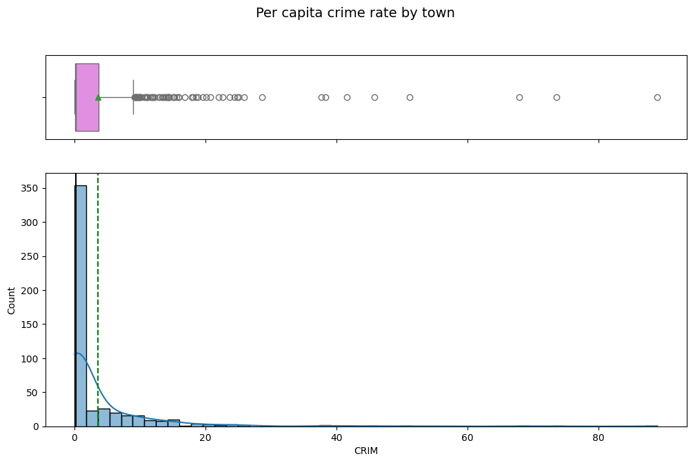

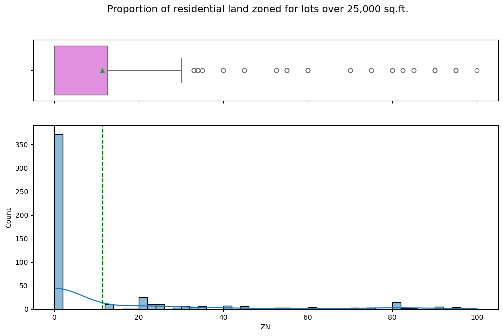

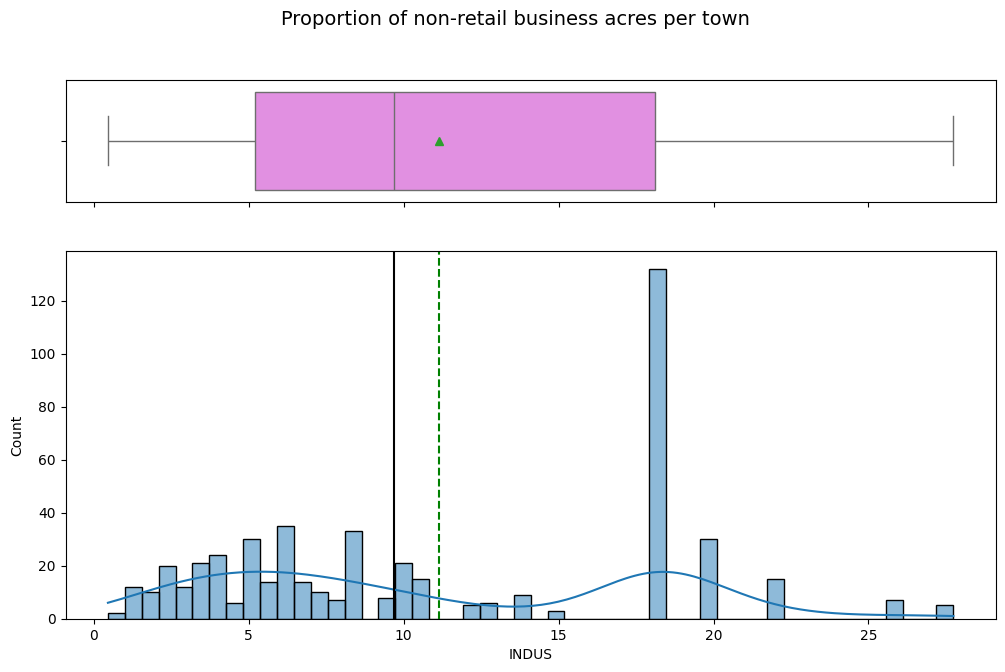

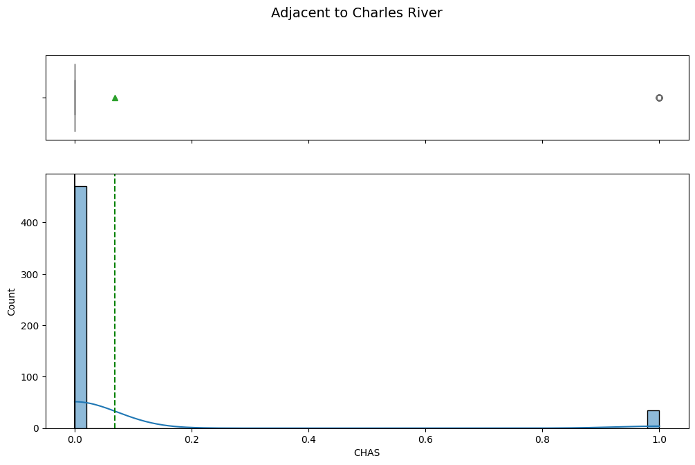

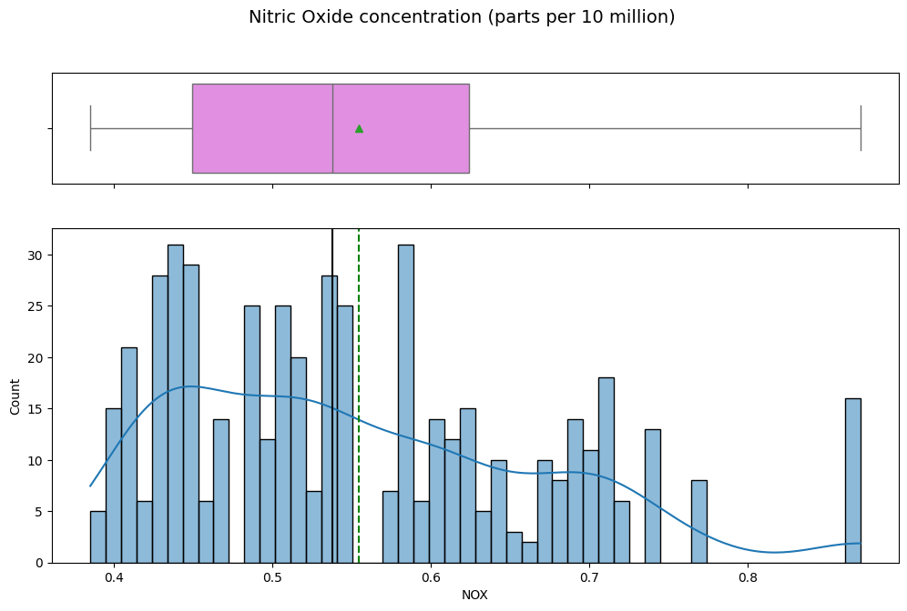

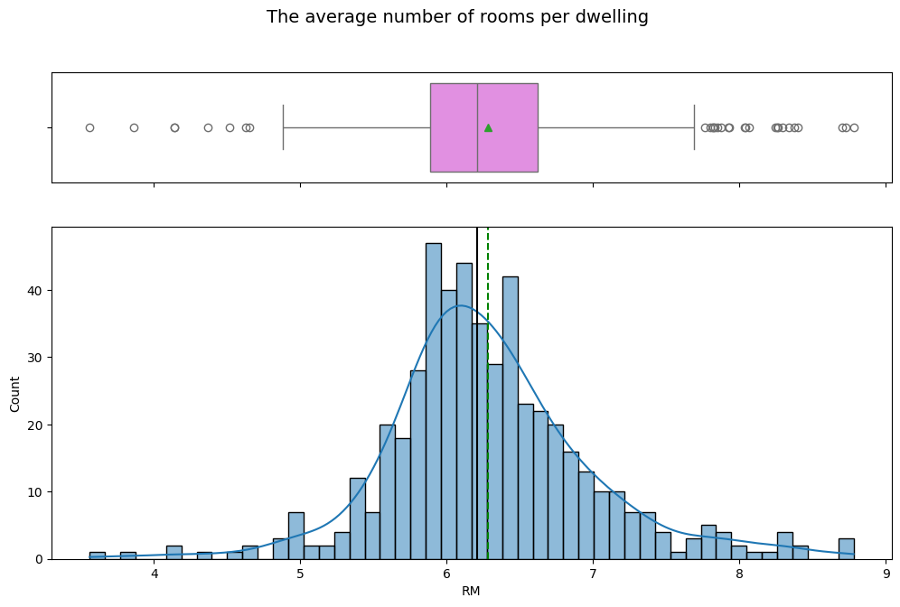

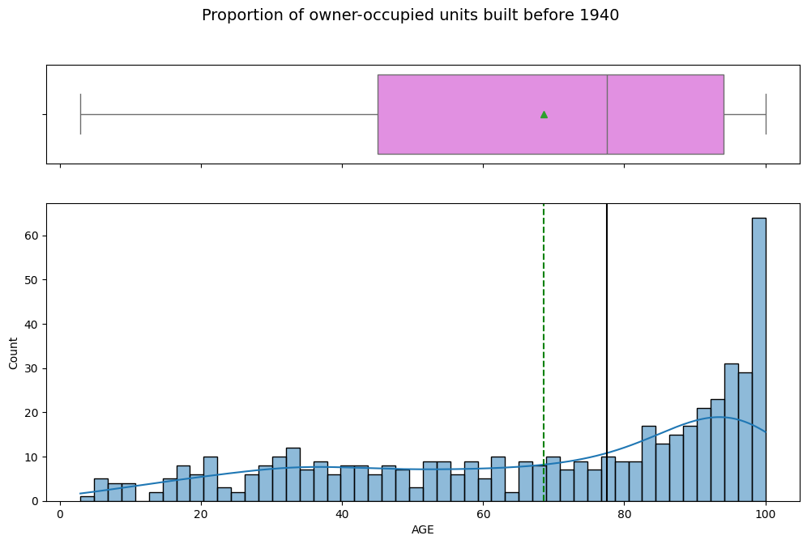

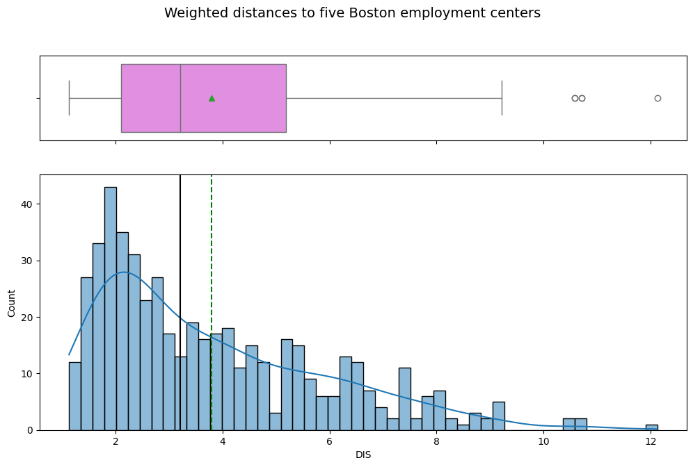

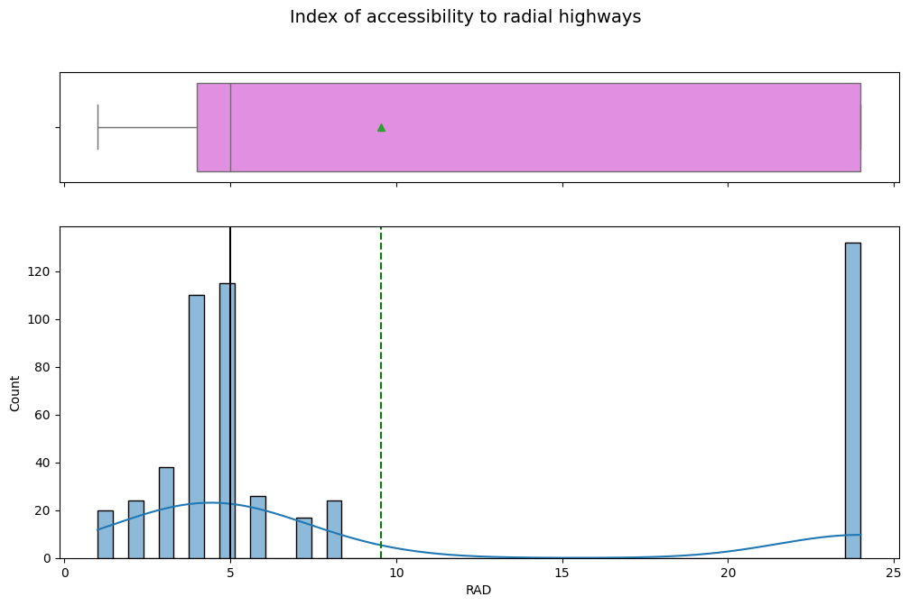

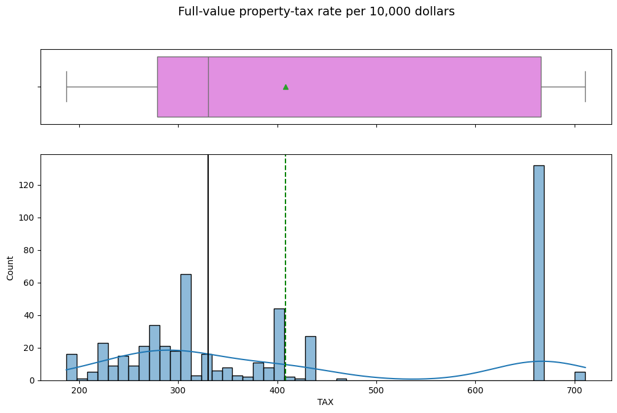

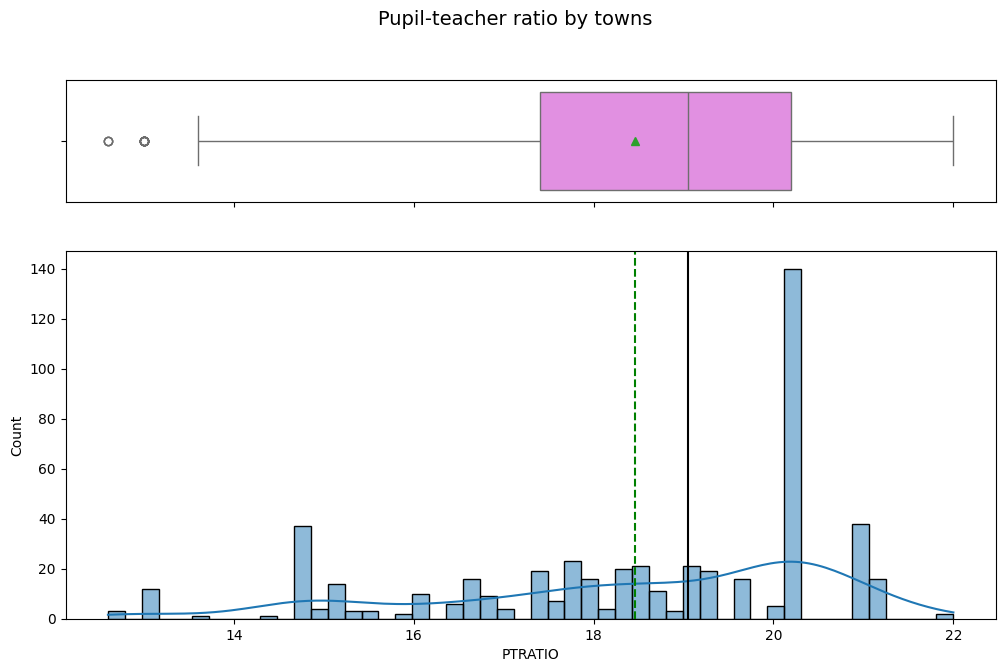

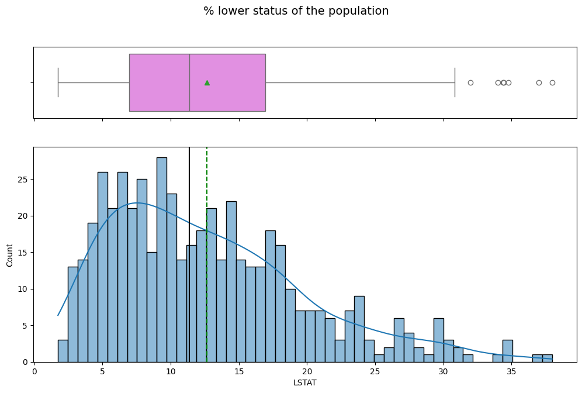

[1 more figures not shown]

```python
# Plot the distributions for all the columns so we can see their distributions
# and detect outliers.

for col, title in cols:
  histogram_boxplot(data, col, title, kde = True, bins = 50)
  plt.show()
  print("-"*130)
```

```python
# The mean of numerical variables grouped by proximity to Charles River
data.groupby(['CHAS']).mean()
```

| CHAS | CRIM | ZN | INDUS | NOX | RM | AGE | DIS | RAD | TAX | PTRATIO | LSTAT | MEDV |
| --- | --- | --- | --- | --- | --- | --- | --- | --- | --- | --- | --- | --- |
| 0 | 3.744447 | 11.634820 | 11.019193 | 0.551817 | 6.267174 | 67.911677 | 3.851915 | 9.566879 | 409.870488 | 18.527176 | 12.757941 | 22.093843 |
| 1 | 1.851670 | 7.714286 | 12.719143 | 0.593426 | 6.519600 | 77.500000 | 3.029709 | 9.314286 | 386.257143 | 17.491429 | 11.241714 | 28.440000 |

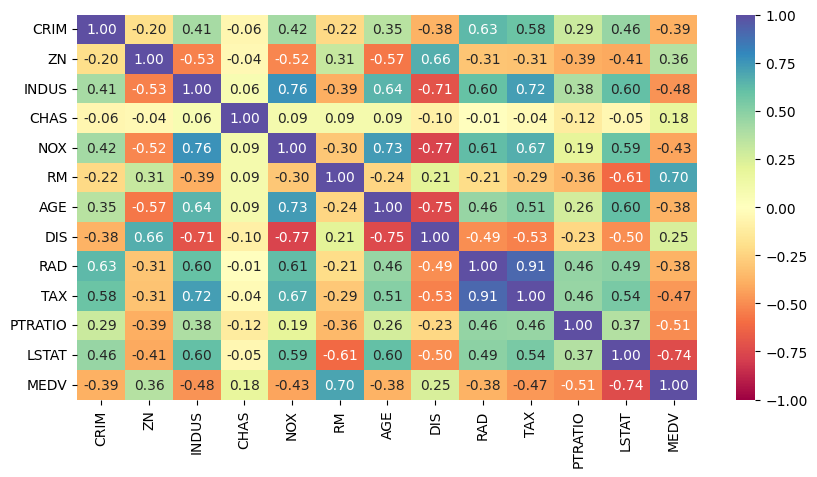

```python
# Plot the heatmap that includes all the columns to get an intial read
# on the correlations between the variables - namely MEDV.
cols_list = data.select_dtypes(include = np.number).columns.tolist()

plt.figure(figsize = (10, 5))
sns.heatmap(
    data[cols_list].corr(), annot = True, vmin = -1, vmax = 1, fmt = ".2f", cmap = "Spectral"
)
plt.show()
```

## Data Preprocessing

- We see no missing values that need treatment.
- Let's do some log transformation on the MEDV to account for a slight bit of skewness.
- A number of our features are scaled differently (e.g. NOX vs TAX). Let's apply scaling to our model to attempt to improve our performance.
- No feature engineering is REQUIRED since all the data is numeric but as you will see below, we will combine a few columns to address some multicollinearity issues.
- Outliers seem to to be valid data points. Treatment of them could lead to biased results.
- We'll need to split our independent variables and target variable.

```python
# Log transform the predictor
data['MEDV'] = np.log(data['MEDV'])
```

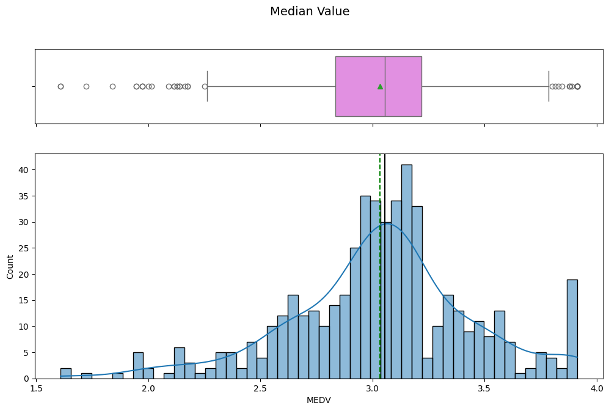

```python
histogram_boxplot(data, 'MEDV', 'Median Value', kde = True, bins = 50)
plt.show()
```

```python
# Separating independent variables and the target variable
x = data.drop('MEDV',axis=1)

y = data['MEDV']
```

```python
# Scaling the data
sc = StandardScaler()
#sc = MinMaxScaler()

X_scaled = sc.fit_transform(x)

X_scaled = pd.DataFrame(X_scaled, columns = x.columns)
```

## Model Building - Linear Regression

First, lets include a few handy functions we can use for model evaluation.

```python
# Function to compute adjusted R-squared
def adj_r2_score(predictors, targets, predictions):
    r2 = r2_score(targets, predictions)
    n = predictors.shape[0]
    k = predictors.shape[1]
    return 1 - ((1 - r2) * (n - 1) / (n - k - 1))


# Function to compute MAPE
def mape_score(targets, predictions):
    return np.mean(np.abs(targets - predictions) / targets) * 100


# Function to compute different metrics to check performance of a regression model
def model_performance_regression(model, predictors, target):
    """
    Function to compute different metrics to check regression model performance

    model: regressor
    predictors: independent variables
    target: dependent variable
    """

    pred = model.predict(predictors)                  # Predict using the independent variables
    r2 = r2_score(target, pred)                       # To compute R-squared
    adjr2 = adj_r2_score(predictors, target, pred)    # To compute adjusted R-squared
    rmse = np.sqrt(mean_squared_error(target, pred))  # To compute RMSE
    mae = mean_absolute_error(target, pred)           # To compute MAE
    mape = mape_score(target, pred)                   # To compute MAPE

    # Creating a dataframe of metrics
    df_perf = pd.DataFrame(
        {
            "RMSE": rmse,
            "MAE": mae,
            "R-squared": r2,
            "Adj. R-squared": adjr2,
            "MAPE": mape,
        },
        index=[0],
    )

    return df_perf
```

#### First let's just run a basic linear regression model against the log, scaled data to see what we get.

```python
# Splitting the dataset into train and test datasets
x_train, x_test, y_train, y_test = train_test_split(X_scaled, y, test_size = 0.2, shuffle = True, random_state = 1)
```

```python
# Checking the shape of the train and test data
print("Shape of Training set : ", x_train.shape)
print("Shape of test set : ", x_test.shape)
```

```
Shape of Training set :  (404, 12)
Shape of test set :  (102, 12)
```

```python
x_train1 = x_train.astype(float)
y_train1 = y_train.astype(float)

import statsmodels.api as sm

# Statsmodel API does not add a constant by default. We need to add it explicitly.
x_train1 = sm.add_constant(x_train1)

# Add constant to test data
x_test1 = sm.add_constant(x_test)

# Train the model
olsmodel1 = sm.OLS(y_train1, x_train1).fit()

# Get the model summary
olsmodel1.summary()
print(olsmodel1.summary())
```

```
                            OLS Regression Results
==============================================================================
Dep. Variable:                   MEDV   R-squared:                       0.783
Model:                            OLS   Adj. R-squared:                  0.777
Method:                 Least Squares   F-statistic:                     117.8
Date:                Mon, 29 Jul 2024   Prob (F-statistic):          1.02e-121
Time:                        22:05:00   Log-Likelihood:                 101.65
No. Observations:                 404   AIC:                            -177.3
Df Residuals:                     391   BIC:                            -125.3
Df Model:                          12
Covariance Type:            nonrobust
==============================================================================
                 coef    std err          t      P>|t|      [0.025      0.975]
------------------------------------------------------------------------------
const          3.0390      0.010    318.099      0.000       3.020       3.058
CRIM          -0.0937      0.012     -7.966      0.000      -0.117      -0.071
ZN             0.0353      0.015      2.334      0.020       0.006       0.065
INDUS          0.0133      0.019      0.717      0.474      -0.023       0.050
CHAS           0.0237      0.009      2.559      0.011       0.005       0.042
NOX           -0.1066      0.020     -5.376      0.000      -0.146      -0.068
RM             0.0478      0.013      3.548      0.000       0.021       0.074
AGE            0.0140      0.017      0.829      0.408      -0.019       0.047
DIS           -0.1064      0.019     -5.493      0.000      -0.145      -0.068
RAD            0.1155      0.027      4.256      0.000       0.062       0.169
TAX           -0.0916      0.030     -3.084      0.002      -0.150      -0.033
PTRATIO       -0.0864      0.013     -6.670      0.000      -0.112      -0.061
LSTAT         -0.2146      0.016    -13.182      0.000      -0.247      -0.183
==============================================================================
Omnibus:                       42.023   Durbin-Watson:                   1.992
Prob(Omnibus):                  0.000   Jarque-Bera (JB):              130.632
Skew:                           0.438   Prob(JB):                     4.30e-29
Kurtosis:                       5.645   Cond. No.                         10.1
==============================================================================

Notes:
[1] Standard Errors assume that the covariance matrix of the errors is correctly specified.
```

## Model Performance Check

```python
lin_reg_train = model_performance_regression(olsmodel1, x_train1, y_train1)
lin_reg_train
```

|  | RMSE | MAE | R-squared | Adj. R-squared | MAPE |
| --- | --- | --- | --- | --- | --- |
| 0 | 0.188143 | 0.135757 | 0.783387 | 0.776166 | 4.720875 |

```python
lin_reg_test = model_performance_regression(olsmodel1, x_test1, y_test)
lin_reg_test
```

|  | RMSE | MAE | R-squared | Adj. R-squared | MAPE |
| --- | --- | --- | --- | --- | --- |
| 0 | 0.201199 | 0.151518 | 0.774987 | 0.741746 | 5.303621 |

```python
from statsmodels.stats.outliers_influence import variance_inflation_factor

# Function to check VIF
def checking_vif(train):
    vif = pd.DataFrame()
    vif["feature"] = train.columns

    # Calculating VIF for each feature
    vif["VIF"] = [
        variance_inflation_factor(train.values, i) for i in range(len(train.columns))
    ]
    return vif

print(checking_vif(x_train1))
```

```
    feature       VIF
0     const  1.008173
1      CRIM  1.725903
2        ZN  2.515170
3     INDUS  3.812858
4      CHAS  1.072320
5       NOX  4.421201
6        RM  1.925194
7       AGE  3.225755
8       DIS  4.205930
9       RAD  8.076667
10      TAX  9.807470
11  PTRATIO  1.859054
12    LSTAT  2.988056
```

#### Key Observations

1. Overall Model Fit
- R-squared (0.783): This indicates that the model explains 78.3% of the variance in the median house value (MEDV). This is a relatively good fit, suggesting the predictors have substantial explanatory power.
- Adjusted R-squared (0.777): This adjusts the R-squared for the number of predictors in the model. It's slightly lower than the R-squared, indicating that some predictors might not contribute significantly to explaining the variance.
- F-statistic (117.8) and Prob (F-statistic) (1.02e-121): The F-statistic tests the overall significance of the model (i.e., whether at least one of the predictors is significantly related to MEDV). The extremely low p-value (<0.05) strongly suggests that your model as a whole is statistically significant.
2. Significant Predictors

The following predictors have p-values less than 0.05 and are therefore considered statistically significant at the conventional level:

- CRIM: crime rate (negative relationship)
- ZN: proportion of residential land zoned for large lots (positive relationship)
- CHAS: Charles River dummy variable (1 if tract bounds river; 0 otherwise) (positive relationship)
- NOX: nitric oxides concentration (negative relationship)
- RM: average number of rooms per dwelling (positive relationship)
- DIS: weighted distances to five Boston employment centers (negative relationship)
- RAD: index of accessibility to radial highways (positive relationship)
- TAX: full-value property-tax rate per $10,000 (negative relationship)
- PTRATIO: pupil-teacher ratio by town (negative relationship)
- LSTAT: % lower status of the population (negative relationship)
3. Non-Significant Predictors
- INDUS: proportion of non-retail business acres per town (p-value > 0.05, not significant)
- AGE: proportion of owner-occupied units built prior to 1940 (p-value > 0.05, not significant)
4. The Variance Inflation Factors (VIF) for a number of the predictors indicate some degree of multicollinearity.

#### Next Steps

So next, let's address the non-significant predictors and combine some of the similarly (positive/negative) highly-correlated independent variables to see what affect they may have on the overall model performance.

```python
# Splitting the dataset into train and test datasets
x_train2, x_test2, y_train2, y_test2 = train_test_split(X_scaled, y, test_size = 0.2, shuffle = True, random_state = 1)
```

```python
# Drop the original 'INDUS' and 'AGE' columns
x_train2 = x_train2.drop(['INDUS', 'AGE'], axis=1)
x_test2 = x_test2.drop(['INDUS', 'AGE'], axis=1)
```

```python
# Combine the two columns RAD and TAX into a single column RADTAX by computing the mean of each row.
x_train2['RADTAX'] = x_train2[['RAD', 'TAX']].mean(axis=1)
x_test2['RADTAX'] = x_test2[['RAD', 'TAX']].mean(axis=1)

# Drop the original 'RAD' and 'TAX' columns
x_train2 = x_train2.drop(['RAD', 'TAX'], axis=1)
x_test2 = x_test2.drop(['RAD', 'TAX'], axis=1)
```

```python
# Combine the two columns RAD and TAX into a single column RADTAX by computing the mean of each row.
x_train2['DISNOX'] = x_train2[['DIS', 'NOX']].mean(axis=1)
x_test2['DISNOX'] = x_test2[['DIS', 'NOX']].mean(axis=1)

# Drop the original 'RAD' and 'TAX' columns
x_train2 = x_train2.drop(['DIS', 'NOX'], axis=1)
x_test2 = x_test2.drop(['DIS', 'NOX'], axis=1)
```

```python
x_train2 = x_train2.astype(float)
y_train2 = y_train2.astype(float)

import statsmodels.api as sm

# Statsmodel API does not add a constant by default. We need to add it explicitly.
x_train2 = sm.add_constant(x_train2)

# Add constant to test data
x_test2 = sm.add_constant(x_test2)

# Train the model
olsmodel2 = sm.OLS(y_train2, x_train2).fit()

# Get the model summary
olsmodel2.summary()
print(olsmodel2.summary())
```

```
                            OLS Regression Results
==============================================================================
Dep. Variable:                   MEDV   R-squared:                       0.775
Model:                            OLS   Adj. R-squared:                  0.770
Method:                 Least Squares   F-statistic:                     169.8
Date:                Mon, 29 Jul 2024   Prob (F-statistic):          8.83e-123
Time:                        22:05:53   Log-Likelihood:                 93.745
No. Observations:                 404   AIC:                            -169.5
Df Residuals:                     395   BIC:                            -133.5
Df Model:                           8
Covariance Type:            nonrobust
==============================================================================
                 coef    std err          t      P>|t|      [0.025      0.975]
------------------------------------------------------------------------------
const          3.0408      0.010    314.377      0.000       3.022       3.060
CRIM          -0.0869      0.012     -7.384      0.000      -0.110      -0.064
ZN             0.0231      0.012      1.914      0.056      -0.001       0.047
CHAS           0.0279      0.009      3.020      0.003       0.010       0.046
RM             0.0566      0.013      4.295      0.000       0.031       0.082
PTRATIO       -0.0853      0.012     -7.105      0.000      -0.109      -0.062
LSTAT         -0.2094      0.014    -14.501      0.000      -0.238      -0.181
RADTAX         0.0298      0.015      2.003      0.046       0.001       0.059
DISNOX        -0.2119      0.032     -6.705      0.000      -0.274      -0.150
==============================================================================
Omnibus:                       43.385   Durbin-Watson:                   1.944
Prob(Omnibus):                  0.000   Jarque-Bera (JB):              154.203
Skew:                           0.405   Prob(JB):                     3.28e-34
Kurtosis:                       5.916   Cond. No.                         5.85
==============================================================================

Notes:
[1] Standard Errors assume that the covariance matrix of the errors is correctly specified.
```

```python
lin_reg_train = model_performance_regression(olsmodel2, x_train2, y_train2)
lin_reg_train
```

|  | RMSE | MAE | R-squared | Adj. R-squared | MAPE |
| --- | --- | --- | --- | --- | --- |
| 0 | 0.191861 | 0.137918 | 0.774741 | 0.769595 | 4.78804 |

```python
lin_reg_test = model_performance_regression(olsmodel2, x_test2, y_test2)
lin_reg_test
```

|  | RMSE | MAE | R-squared | Adj. R-squared | MAPE |
| --- | --- | --- | --- | --- | --- |
| 0 | 0.209767 | 0.158669 | 0.755415 | 0.731488 | 5.570191 |

```python
from statsmodels.stats.outliers_influence import variance_inflation_factor

# Function to check VIF
def checking_vif(train):
    vif = pd.DataFrame()
    vif["feature"] = train.columns

    # Calculating VIF for each feature
    vif["VIF"] = [
        variance_inflation_factor(train.values, i) for i in range(len(train.columns))
    ]
    return vif

print(checking_vif(x_train2))
```

```
   feature       VIF
0    const  1.003901
1     CRIM  1.680874
2       ZN  1.552740
3     CHAS  1.034800
4       RM  1.789990
5  PTRATIO  1.553878
6    LSTAT  2.283393
7   RADTAX  2.269509
8   DISNOX  1.272334
```

#### Observations

- Both models are slightly overfit with 80% of the data being used for training.
- Both models explain a large portion of the variance in MEDV, with olsmodel1 slightly edging out olsmodel2 in both R-squared (.783 vs .774) and Adjusted R-squared (.777 vs .770). However, the difference is minor.
- Both models have very high F-statistics, indicating that both models are statistically significant overall. Olsmodel2 has a higher F-statistic, suggesting that it may be a slightly better fit overall.

Let's try a Ridge Regression to see if we can reduce the overfitting just a bit.

```python
# Create and fit the Ridge regression model
ridge_model = sm.OLS(y_train2, x_train2).fit_regularized(method='elastic_net', L1_wt=0)  # alpha controls regularization strength
print("*************Parameters**************")
print(ridge_model.params)

# Predictions on training data
y_pred = ridge_model.predict(x_train2)

# Calculate metrics manually
mse = mean_squared_error(y_train2, y_pred)
mae = mean_absolute_error(y_train2, y_pred)
r2 = r2_score(y_train2, y_pred)

print("\nRidge Model Fit Statistics:")
print(f"  MSE: {mse:.4f}")
print(f"  MAE: {mae:.4f}")
print(f"  R-squared: {r2:.4f}")
```

```
*************Parameters**************
[ 3.04077924 -0.08693428  0.02305922  0.02786661  0.05656798 -0.08533993
 -0.20937214  0.02975333 -0.21194447]

Ridge Model Fit Statistics:
  MSE: 0.0368
  MAE: 0.1379
  R-squared: 0.7747
```

Ridge regression set up in a slightly different manner with built-in cross validatation.

```python
from sklearn.linear_model import RidgeCV

# Ridge Regression with Cross-Validation for Optimal Alpha:
alphas = [0.01, 0.1, 1, 10, 100]  # Range of alpha values to test
ridge_cv = RidgeCV(alphas=alphas, scoring='neg_mean_squared_error', cv=5)  # 5-fold cross-validation
ridge_cv.fit(x_train2, y_train2)

print(f"Best alpha (lambda) value found by CV: {ridge_cv.alpha_:.4f}")

# Fit the Ridge Model with the Best Alpha:
#ridge_model = sm.OLS(y_train2, x_train2).fit_regularized(method='elastic_net', L1_wt=0, alpha=ridge_cv.alpha_)
# NOTE: The RidgeCV() picked an alpha = 1 which produced an awful R-squared.  Overriding
# with a very small value found via manual trial and error...
ridge_model = sm.OLS(y_train2, x_train2).fit_regularized(method='elastic_net', L1_wt=0, alpha=.001)

# 3. Get Predictions and Evaluate:
y_pred = ridge_model.predict(x_train2)

mse = mean_squared_error(y_train2, y_pred)
mae = mean_absolute_error(y_train2, y_pred)
r2 = r2_score(y_train2, y_pred)

print("\nRidge Model Fit Statistics:")
print(f"  MSE: {mse:.4f}")
print(f"  MAE: {mae:.4f}")
print(f"  R-squared: {r2:.4f}")

# (Optional) Display coefficients
print("\nRidge Coefficients:")
print(ridge_model.params)
```

```
Best alpha (lambda) value found by CV: 1.0000

Ridge Model Fit Statistics:
  MSE: 0.0368
  MAE: 0.1378
  R-squared: 0.7747

Ridge Coefficients:
[ 3.03772196 -0.0866635   0.02286327  0.02796252  0.05679953 -0.08508855
 -0.20899613  0.0289942  -0.2096794 ]
```

Llikewise, let's try a Lasso Regression ...

```python
# Create and fit the Lasso regression model
lasso_model = sm.OLS(y_train2, x_train2).fit_regularized(method='elastic_net', L1_wt=1)  # alpha controls regularization strength
print("*************Parameters**************")
print(lasso_model.params)

# Predictions on training data
y_pred = lasso_model.predict(x_train2)

# Calculate metrics manually
mse = mean_squared_error(y_train2, y_pred)
mae = mean_absolute_error(y_train2, y_pred)
r2 = r2_score(y_train2, y_pred)

print("\nLasso Model Fit Statistics:")
print(f"  MSE: {mse:.4f}")
print(f"  MAE: {mae:.4f}")
print(f"  R-squared: {r2:.4f}")
```

```
*************Parameters**************
const      3.040779
CRIM      -0.086934
ZN         0.023059
CHAS       0.027867
RM         0.056568
PTRATIO   -0.085340
LSTAT     -0.209372
RADTAX     0.029753
DISNOX    -0.211944
dtype: float64

Lasso Model Fit Statistics:
  MSE: 0.0368
  MAE: 0.1379
  R-squared: 0.7747
```

Lasso regression set up in a slightly different manner with built-in cross validatation.

```python
from sklearn.linear_model import LassoCV

# Lasso Regression with Cross-Validation for Optimal Alpha:
alphas = [0.01, 0.1, 1, 10, 100]  # Range of alpha values to test
lasso_cv = LassoCV(alphas=alphas, cv=5)  # 5-fold cross-validation
lasso_cv.fit(x_train2, y_train2)

print(f"Best alpha (lambda) value found by CV: {lasso_cv.alpha_:.4f}")

# Fit the Lasso Model with the Best Alpha:
# NOTE: The LassoCV() picked an alpha = .01 which produced an awful R-squared.  Overriding
# with a very small value found via manual trial and error...
lasso_model = sm.OLS(y_train2, x_train2).fit_regularized(method='elastic_net', L1_wt=1, alpha=.001)

# 3. Get Predictions and Evaluate:
y_pred = lasso_model.predict(x_train2)

mse = mean_squared_error(y_train2, y_pred)
mae = mean_absolute_error(y_train2, y_pred)
r2 = r2_score(y_train2, y_pred)

print("\nLasso Model Fit Statistics:")
print(f"  MSE: {mse:.4f}")
print(f"  MAE: {mae:.4f}")
print(f"  R-squared: {r2:.4f}")

# (Optional) Display coefficients
print("\nLasso Coefficients:")
print(lasso_model.params)
```

```
Best alpha (lambda) value found by CV: 0.0100

Lasso Model Fit Statistics:
  MSE: 0.0368
  MAE: 0.1376
  R-squared: 0.7746

Lasso Coefficients:
const      3.039712
CRIM      -0.084241
ZN         0.020356
CHAS       0.027115
RM         0.057480
PTRATIO   -0.083280
LSTAT     -0.208718
RADTAX     0.023925
DISNOX    -0.198305
dtype: float64
```

## Checking Linear Regression Assumptions

### **Checking the below linear regression assumptions**

In order to make statistical inferences from a linear regression model, it is important to ensure that the assumptions of linear regression are satisfied.

1. **Mean of residuals should be 0**
2. **No Heteroscedasticity**
3. **Linearity of variables**
4. **Normality of error terms**

```python
# Mean of residuals should be near zero
residuals = olsmodel2.resid
np.mean(residuals)
```

```
5.386230515508185e-16
```

```python
# Check for homoscedacity
from statsmodels.stats.diagnostic import het_white
from statsmodels.compat import lzip
import statsmodels.stats.api as sms
import statsmodels.stats.api as sms
from statsmodels.compat import lzip

name = ["F statistic", "p-value"]
test = sms.het_goldfeldquandt(y_train2, x_train2)
lzip(name, test)
```

```
[('F statistic', 1.0657075820687707), ('p-value', 0.32944687426490854)]
```

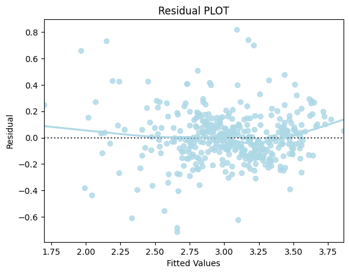

```python
# Predicted values
fitted = olsmodel2.fittedvalues

# sns.set_style("whitegrid")
sns.residplot(x = fitted, y = residuals, color = "lightblue", lowess = True)

plt.xlabel("Fitted Values")

plt.ylabel("Residual")

plt.title("Residual PLOT")

plt.show()
```

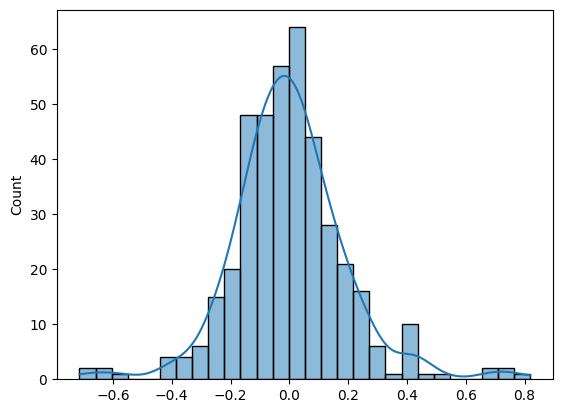

```python
# Plot histogram of residuals
sns.histplot(residuals, kde = True)
```

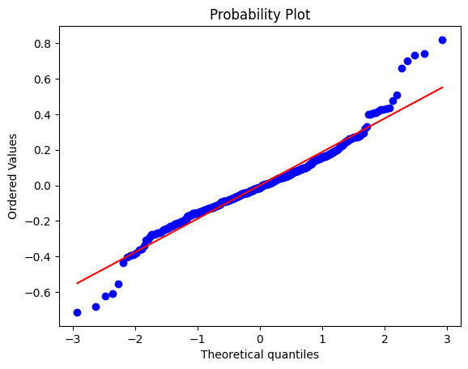

```python
# Plot q-q plot of residuals
import pylab

import scipy.stats as stats

stats.probplot(residuals, dist = "norm", plot = pylab)

plt.show()
```

#### Cross Validation

Let's check the performance of the model using the cross-validation technique from the scikit-learn library and see if the performance on the train and the test data is comparable to what we are getting after cross-validating the data.

```python
# Import the required function
from sklearn.model_selection import cross_val_score

# Build the regression model and cross-validate
linearregression = LinearRegression()

cv_Score11 = cross_val_score(linearregression, x_train2, y_train2, cv = 10)
cv_Score12 = cross_val_score(linearregression, x_train2, y_train2, cv = 10,
                             scoring = 'neg_mean_squared_error')


print("RSquared: %0.3f (+/- %0.3f)" % (cv_Score11.mean(), cv_Score11.std() * 2))
print("Mean Squared Error: %0.3f (+/- %0.3f)" % (-1*cv_Score12.mean(), cv_Score12.std() * 2))
```

```
RSquared: 0.732 (+/- 0.212)
Mean Squared Error: 0.040 (+/- 0.020)
```

#### Model Performance

Our model demonstrates the predictive power with an average R-squared of 0.732. This means it captures a substantial portion of the factors influencing house prices. However, the variability in R-squared across folds suggests the model's performance might not be entirely consistent across different data samples.

## Final Model

Both models have similar overall performance and predictive power. Model2 is given the edge only because it is simpler with insignificant features removed and multicollinearity isses handled. Below is a plot of its prices vs predicted prices.

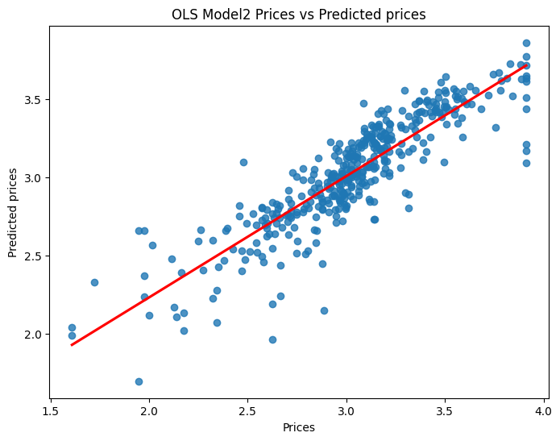

```python
# Model prediction on train data
y_pred = olsmodel2.predict(x_train2)

# Visualize
plt.figure(figsize=(8, 6))
sns.regplot(x=y_train2, y=y_pred, ci=None, line_kws={'color':'red'})  # Trend line with seaborn

# Add confidence intervals
#plt.fill_between(y_train1, y_pred_ci_lower, y_pred_ci_upper, color='red', alpha=0.1)  # Confidence band

plt.xlabel("Prices")
plt.ylabel("Predicted prices")
plt.title("OLS Model2 Prices vs Predicted prices")
plt.show()
```

## Actionable Insights and Recommendations

Based on our linear regression model's summary, here are some actionable insights we can derive to understand and predict housing prices in the Boston area:

### **Investment/Policy Decisions**

The insights can inform real estate investment strategies, urban planning decisions, and policy-making. For example, investing in areas with lower crime rates, proximity to the Charles River, good schools, and lower pollution levels might yield higher returns.

### **Homebuyers/Sellers**

Individuals can use this information to make more informed decisions about buying or selling properties. They can prioritize neighborhoods with desirable characteristics based on the model's coefficients.

### **Recommendations**

We should consider non-linear models such as Random Forest or XGBoost to refine the analysis and gain deeper insights.